# Final Project Schmittj21

John Schmitt

24 April, 2020

### Load Packages

```r
library(knitr)
library(tidyverse)
library(dplyr)
library(RMySQL)
```

### Database Connection

```r
library(nycflights13)
```

```r
db = dbConnect(MySQL(),
  user = 'schmittj21',
  password = '1734571',
  dbname = 'online_retailer',
  host = 'ballenger.wlu.edu')

knitr::opts_knit$set(sql.max.print = -1)
```

### Load Data

```r
flights_data <- flights
airline_data <- airlines
planes_data <- planes
weather_data <- weather
airports_data <- airports
```

### Question 1

```r
flights_data %>%
   count(dest) %>%
   arrange(desc(n)) %>%
  rename(Count = n) %>%
  rename(Destination = dest) %>%
   head(10)
```

```
## # A tibble: 10 x 2
##    Destination Count
##    <chr>       <int>
##  1 ORD         17283
##  2 ATL         17215
##  3 LAX         16174
##  4 BOS         15508
##  5 MCO         14082
##  6 CLT         14064
##  7 SFO         13331
##  8 FLL         12055
##  9 MIA         11728
## 10 DCA          9705
```

To solve this problem, I slimply referenced the data, by calling on flights_data, including a pipe. After i counted the amount of times each airport was a flight’s destination. Since all the data is from NYC, there is no need to fliter the data. I arranged these counts in descinding order and used the head function to only include the first ten results. Last, I renamed all column headings so that they were user friendly.

### Question 2

```r
flights_data %>%
  count(carrier) %>%
arrange(desc(n)) %>%
inner_join(airline_data, by = "carrier") %>%
rename(Count = n) %>%
rename(Airline = carrier) %>%
rename(Carrier_Name = name)
```

```
## # A tibble: 16 x 3
##    Airline Count Carrier_Name
##    <chr>   <int> <chr>
##  1 UA      58665 United Air Lines Inc.
##  2 B6      54635 JetBlue Airways
##  3 EV      54173 ExpressJet Airlines Inc.
##  4 DL      48110 Delta Air Lines Inc.
##  5 AA      32729 American Airlines Inc.
##  6 MQ      26397 Envoy Air
##  7 US      20536 US Airways Inc.
##  8 9E      18460 Endeavor Air Inc.
##  9 WN      12275 Southwest Airlines Co.
## 10 VX       5162 Virgin America
## 11 FL       3260 AirTran Airways Corporation
## 12 AS        714 Alaska Airlines Inc.
## 13 F9        685 Frontier Airlines Inc.
## 14 YV        601 Mesa Airlines Inc.
## 15 HA        342 Hawaiian Airlines Inc.
## 16 OO         32 SkyWest Airlines Inc.
```

To solve this problem, I took an approcah very similiar to question 1.I slimply referenced the data, by calling on flights_data, including pipes where neccessary throughout. After I counted the amount of times each carrier was a flight’s carrier. Since all the data is from NYC, there is no need to fliter the data. I arranged these counts in descinding order, completing the problem. Last, I renamed all column headings so that they were user friendly.

### Question 3

```r
flights_data %>%
  inner_join(airline_data, by = "carrier") %>%
  filter(arr_delay != "NA") %>%
  group_by(carrier, name) %>%
  summarise(mean_arr_delay = mean(arr_delay)) %>%
  mutate(mean_arr_delay = round(mean_arr_delay, digits = 2)) %>%
  arrange(desc(mean_arr_delay)) %>%
  rename(Airline = carrier) %>%
  rename(Average_Arrival_Delay = mean_arr_delay) %>%
  rename(Carrier_Name = name)
```

```
## # A tibble: 16 x 3
## # Groups:   Airline [16]
##    Airline Carrier_Name                Average_Arrival_Delay
##    <chr>   <chr>                                       <dbl>
##  1 F9      Frontier Airlines Inc.                      21.9
##  2 FL      AirTran Airways Corporation                 20.1
##  3 EV      ExpressJet Airlines Inc.                    15.8
##  4 YV      Mesa Airlines Inc.                          15.6
##  5 OO      SkyWest Airlines Inc.                       11.9
##  6 MQ      Envoy Air                                   10.8
##  7 WN      Southwest Airlines Co.                       9.65
##  8 B6      JetBlue Airways                              9.46
##  9 9E      Endeavor Air Inc.                            7.38
## 10 UA      United Air Lines Inc.                        3.56
## 11 US      US Airways Inc.                              2.13
## 12 VX      Virgin America                               1.76
## 13 DL      Delta Air Lines Inc.                         1.64
## 14 AA      American Airlines Inc.                       0.36
## 15 HA      Hawaiian Airlines Inc.                      -6.92
## 16 AS      Alaska Airlines Inc.                        -9.93
```

Solving this problem, I first called on flight data, grouping my carrier to get the results for each character. Third, I used a filter function to get rid of all the data with non-aplicalble results. Last, I caculated the mean of the arrival delay time. Additionally, i added pipes where neccessary, throughout the code chunk. Finally, I renamed all column headings and rounded so that they were user friendly.

### Question 4

```r
flights_data %>%
  select(dep_delay, month, day, origin) %>%
  arrange(desc(dep_delay)) %>%
  rename(Departure_Delay = dep_delay) %>%
  rename(Month = month) %>%
  rename(Flight_Origin = origin) %>%
  rename(Day = day)%>%
  head(1)
```

```
## # A tibble: 1 x 4
##   Departure_Delay Month   Day Flight_Origin
##             <dbl> <int> <int> <chr>
## 1            1301     1     9 JFK
```

```r
weather_data %>%
  filter( month == 1, day ==9, origin == "JFK") %>%
  summarise(mean_temp = mean(temp)) %>%
  mutate(mean_temp = round(mean_temp, digits = 2)) %>%
  rename(Mean_Temperature = mean_temp)
```

```
## # A tibble: 1 x 1
##   Mean_Temperature
##              <dbl>
## 1             42.7
```

```r
flights_data %>%
arrange(desc(dep_delay)) %>%
head(1) %>%
inner_join(weather_data, by = c("month", "day", "origin")) %>%
inner_join(airports_data, by = c("origin" = "faa")) %>%
group_by(dep_delay, month, day, origin, name) %>%
summarise(mean_temp =mean(temp)) %>%
mutate(mean_temp = round(mean_temp, digits = 2)) %>%
arrange(desc(dep_delay)) %>%
 rename(Departure_Delay = dep_delay) %>%
 rename(Month = month) %>%
 rename(Flight_Origin = origin) %>%
 rename(Day = day) %>%
 rename(Airport_Name = name) %>%
 rename(Mean_Temperature = mean_temp) %>%
 head(1)
```

```
## # A tibble: 1 x 6
## # Groups:   Departure_Delay, Month, Day, Flight_Origin [1]
##   Departure_Delay Month   Day Flight_Origin Airport_Name        Mean_Temperature
##             <dbl> <dbl> <int> <chr>         <chr>                          <dbl>
## 1            1301     1     9 JFK           John F Kennedy Intl             42.7
```

Solving this question involved three parts. For Part 1, I simply selected the orgin of flights, month and day of the flights, and the departure delay times. After, i arranged these results by departure times in descending order and used the head function to only return the first row. Part 2 requried me to call on the weather data and use a filter to hard codes the date returned from the preivous code chunk. After i use a summarise function to find the mean temperature and use the arrange to return the mean temperrature. Last, I renamed all column headings and rounded so that the information was user friendly.

### Exercise 5

```r
Flight_Time_Buckets <- flights_data %>%
  mutate(time_interval = case_when(
    sched_dep_time >= 001  &
      sched_dep_time <= 600  ~ "12:01am-6am",
    sched_dep_time >= 601  &
      sched_dep_time <= 1200 ~ "6:01am-12pm",
    sched_dep_time >= 1201 &
      sched_dep_time <= 1800 ~ "12:01pm-6pm",
    sched_dep_time >= 1801 &
      sched_dep_time <= 2400 ~ "6:01pm-12am"))
```

```r
Flight_Time_Buckets %>%
  filter(dep_delay != "NA") %>%
  group_by(time_interval) %>%
  mutate(dep_delayed = ifelse(dep_delay > 0, "delayed", "ontime")) %>%
  count(time_interval, dep_delayed) %>%
  mutate(proportion_of_flights_delayed = n / sum(n)) %>%
  mutate(proportion_of_flights_delayed = round(proportion_of_flights_delayed, digits = 2)) %>%
  filter(dep_delayed == "delayed") %>%
  arrange(proportion_of_flights_delayed) %>%
 rename(Departure_Delay = dep_delayed) %>%
 rename(Time_Interval = time_interval) %>%
 rename(Count = n) %>%
rename(Proportion_of_Flights_Delayed = proportion_of_flights_delayed)
```

```
## # A tibble: 4 x 4
## # Groups:   Time_Interval [4]
##   Time_Interval Departure_Delay Count Proportion_of_Flights_Delayed
##   <chr>         <chr>           <int>                         <dbl>
## 1 12:01am-6am   delayed          1819                          0.21
## 2 6:01am-12pm   delayed         32466                          0.26
## 3 12:01pm-6pm   delayed         58325                          0.46
## 4 6:01pm-12am   delayed         35822                          0.52
```

Part 1 of this exercise dictates the user first calls on the flights data, also creating a vector to call on these results later. After I used the mutate function to create a variable, bucketing the scheduled departure times of each flight into four different buckets, giving them a name which reflected thier respective time blocks. Moving into Part 2, we call on the vector previously created an begin by filtering out all the N/A data. After i group by time_interval to display the data by time bucket.I use the iflese to indicate the status of each flight and count to sum the departures that are delayed within each time interval. Afterward, i created a variable to create a porportion of the flights delayed using a mutate function. I then filter to only show the flights that are delayed using a filter function and arrange, to show the porportion of flights delayed. Finally, I renamed all column headings so that they were user friendly.

### Exercise 6

```r
flights_data %>%
  inner_join(planes_data, by = "tailnum") %>%
  select(air_time, dest, tailnum, seats) %>%
   head(1) %>%
  arrange(desc(air_time)) %>%
  rename(Tail_Number = tailnum) %>%
  rename(Seats = seats) %>%
  rename(Destination = dest) %>%
  rename(Air_Time = air_time)
```

```
## # A tibble: 1 x 4
##   Air_Time Destination Tail_Number Seats
##      <dbl> <chr>       <chr>       <int>
## 1      227 IAH         N14228        149
```

### Exercise 7

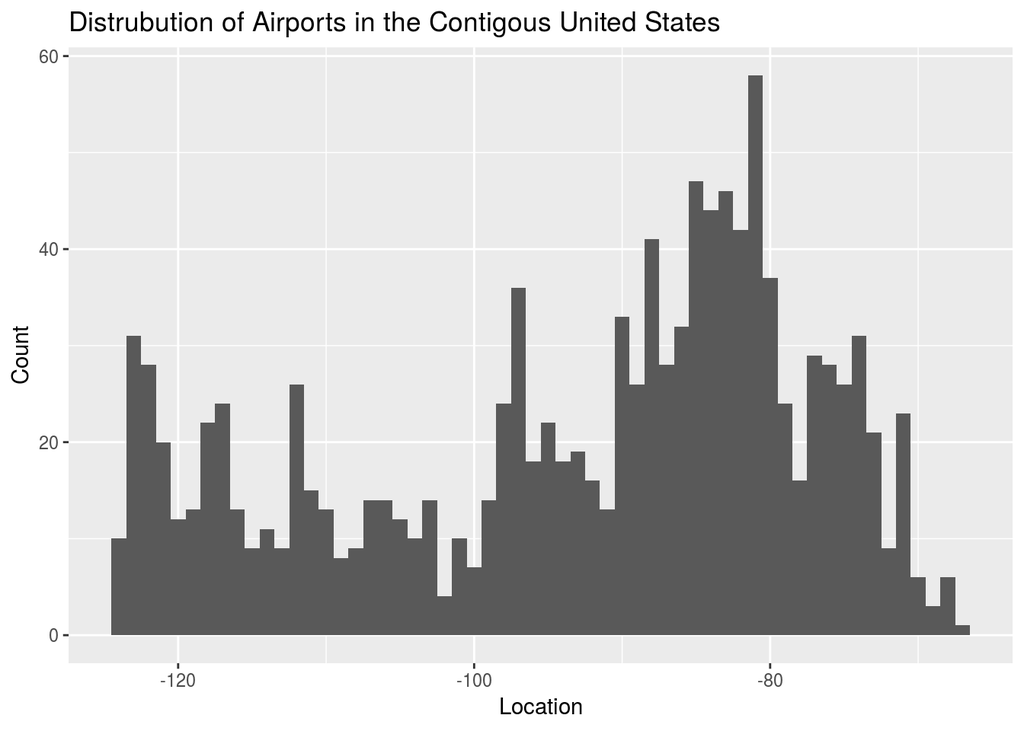

```r
airports_data %>%
  filter(
     lat > 24.520833333333332 & lat < 49.38447222222222,
     lon > -124.77169444444445 & lon < -66.94702777777778) %>%
  ggplot(aes(x = lon)) + geom_histogram(binwidth = 1) +
  labs(title = "Distrubution of Airports in the Contigous United States",
    x = "Location",
    y = "Count")
```

### Exercise 8

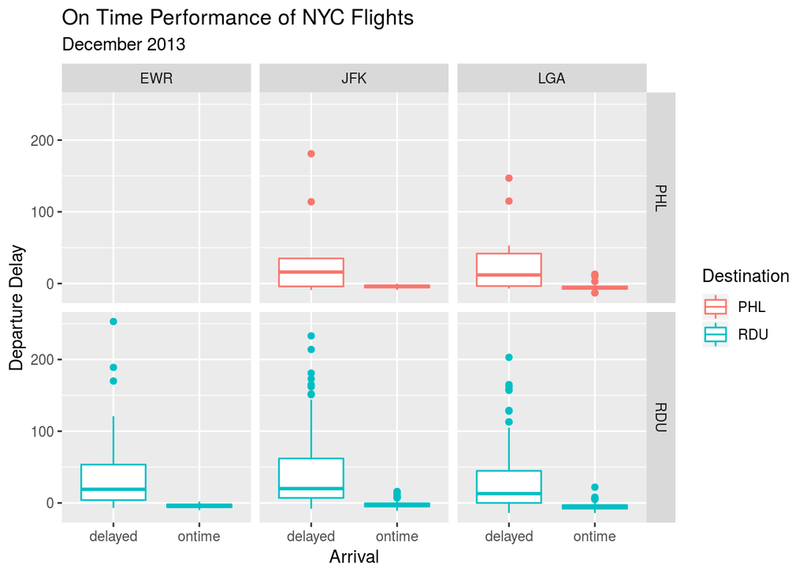

```r
flights_data %>%
  filter(month == 12, dest %in% c("PHL", "RDU")) %>%
  mutate(arrival = ifelse(arr_delay > 0, "delayed", "ontime")) %>%
  filter(arrival != "NA") %>%
  ggplot(aes(x = arrival, y = dep_delay, color = dest)) +
  geom_boxplot() +
  facet_grid(dest ~ origin) +
  labs(title = "On Time Performance of NYC Flights",
    subtitle = "December 2013",
    x = "Arrival",
    y = "Departure Delay",
    color = "Destination")
```

In order to start recreating the plot, i started by calling on flights data. Next, a fliter function to isolate data from December and limit destinations RDU and PHL. I used the mutate function again to create a new variable called arrival and ifelse to help indicate delayed vs. ontime flights. After i used the filter again, to filter out all “NA” data. Next, I used the ggplot function to create a boxplot. We assinged the x axis to measure arrival, the y axis to measure department delay, and the color to indicate destination. After we used the geom_boxplot function to finally create the acutal image. The facet_grid function helps create the display of multiple graphs. The remainder of the code seeks to title axises and titles of the graph in accordance with the directions.

### Exercise 9

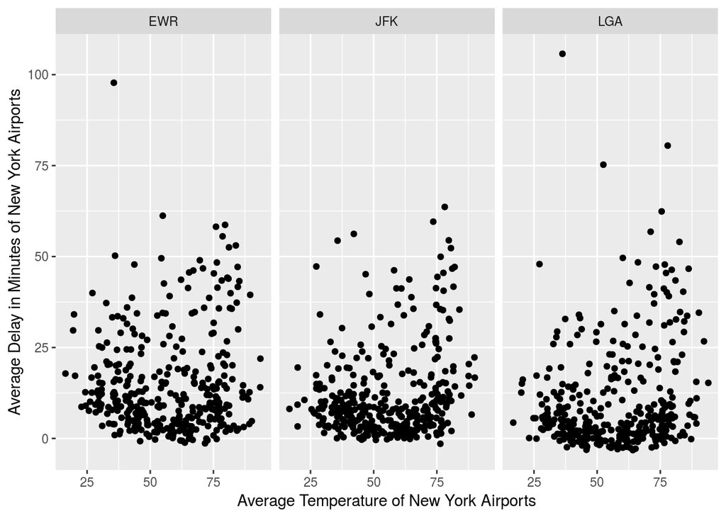

```r
flights_weather_data <- inner_join(flights_data, weather_data, by = c("year", "month", "day", "origin","hour")) %>%
  group_by(month, day, origin) %>%
  summarise(avg_dep_delay = mean(dep_delay, na.rm = TRUE),
            avg_temp = mean(temp, na.rm = TRUE))
  ggplot(flights_weather_data, aes(x = avg_temp, y = avg_dep_delay)) +
            geom_point() +
            facet_wrap(~ origin) +
  labs(x = "Average Temperature of New York Airports", y = "Average Delay in Minutes of New York Airports")
```

First we create a vector called flights_weather_data which is an innerjoin of flights data and weather data on year, day, flight origin, and hour. Without all of these variables, the program will crash (I learned the hard way). After I used the group by function to select the results by the month, day, and origin. After I summarize to get the means, using the na.rm fucntion to remove N/A data. Next, ggplot is referenced to prompt the setting up geom_point function to create a scatterplot. After using the facet function to create the three different figures, i used the labs fucntion to rename the axises.

### Exercise 10

```sql
SELECT customers.Country,
Count(customers.Customer_ID) as Nbr_Customer
FROM customers
Group By(customers.country)
ORDER BY (Count(customers.Customer_ID)) DESC
;
```

37 records

| Country | Nbr_Customer |
| --- | --- |
| United Kingdom | 3950 |
| Germany | 95 |
| France | 87 |
| Spain | 29 |
| Belgium | 24 |
| Portugal | 19 |
| Switzerland | 19 |
| Italy | 15 |
| Finland | 12 |
| Austria | 11 |
| Norway | 10 |
| Netherlands | 9 |
| Channel Islands | 9 |
| Australia | 9 |
| Sweden | 8 |
| Japan | 8 |
| Denmark | 7 |
| Cyprus | 7 |
| Poland | 6 |
| USA | 4 |
| Greece | 4 |
| Unspecified | 4 |
| Canada | 4 |
| Israel | 4 |
| EIRE | 3 |
| Malta | 2 |
| United Arab Emirates | 2 |
| Bahrain | 2 |
| Saudi Arabia | 1 |
| Iceland | 1 |
| European Community | 1 |
| Czech Republic | 1 |
| Brazil | 1 |
| RSA | 1 |
| Lithuania | 1 |
| Lebanon | 1 |
| Singapore | 1 |

For this problem, we must allow the use of SQL in our r inline code. To do this, I referrenced the the db connection to acess the SQL data. After i wrote SQL code, using a select statement to select the country and customer ID, which I counted and renamed nbr_customer. After, I grouped by country to see the results by country and ordered them in descending order, according to the number of customers by using an order by and descending statement.I renamed all column headings so that they were user friendly.

### Exercise 11

```r
EU_countries <- read.csv("eucountries.csv", header = TRUE)
```

```r
countries_ALL <- dbSendQuery(db, 'SELECT
                              customers.Country,
                              customers.Customer_ID,
                              invoices.invoice_date,
                              invoice_products.invoice_no as "invoice_nbr",
                              invoice_products.SKU,
                              products.description,
                              invoice_products.quantity,
                              invoice_products.actual_unit_price
        FROM Customers
        JOIN invoices USING (customer_id)
        JOIN invoice_products USING (invoice_no)
        JOIN products USING (SKU)
        WHERE country != "United Kingdom"')

OLR_EU_Product_Sales <- fetch(countries_ALL, n=-1)
OLR_EU_Product_Sales <- OLR_EU_Product_Sales %>%
  mutate(invoice_date = as.Date(invoice_date)) %>%
  mutate(line_item_total = (quantity * actual_unit_price)) %>%
  mutate(year_month = format(invoice_date, '%Y-%m')) %>%
  filter(Country%in%EU_countries$Country)

glimpse(OLR_EU_Product_Sales)
```

```
## Observations: 30,321
## Variables: 10
## $ Country           <chr> "Finland", "Finland", "Finland", "Finland", "Finl...
## $ Customer_ID       <int> 12348, 12348, 12348, 12348, 12348, 12348, 12348, ...
## $ invoice_date      <date> 2010-12-16, 2010-12-16, 2010-12-16, 2010-12-16, ...
## $ invoice_nbr       <chr> "539318", "539318", "539318", "539318", "539318",...
## $ SKU               <chr> "21211", "21213", "21725", "21977", "21981", "219...
## $ description       <chr> "SET OF 72 SKULL PAPER  DOILIES", "PACK OF 72 SKU...
## $ quantity          <dbl> 72, 144, 48, 144, 144, 144, 72, 72, 144, 48, 144,...
## $ actual_unit_price <dbl> 1.45, 0.55, 0.85, 0.55, 0.29, 0.29, 0.29, 0.55, 0...
## $ line_item_total   <dbl> 104.40, 79.20, 40.80, 79.20, 41.76, 41.76, 20.88,...
## $ year_month        <chr> "2010-12", "2010-12", "2010-12", "2010-12", "2010...
```

```r
Sales_by_month <- OLR_EU_Product_Sales %>%
group_by(year_month) %>%
filter(line_item_total != "NA") %>%
filter(year_month != "2011-12") %>%
summarise(total_monthly_sales = sum(line_item_total))
glimpse(Sales_by_month)
```

```
## Observations: 12
## Variables: 2
## $ year_month          <chr> "2010-12", "2011-01", "2011-02", "2011-03", "20...
## $ total_monthly_sales <dbl> 48391.02, 86256.87, 52224.18, 81433.60, 30489.4...
```

Attempting this problem required that I first download the eucountries.csv file into my r studio. After referenceing the approriate vector to select the data, I then used the send db query function to begin typing SQL. I used a select statement to select the required columns, renaming them appripriately. After, I use the from statement to reference customers. Next, I used join statements to the invoice, invoice_products, and products tables, each on thier appropriate shared columns. Lastly, i use a where function to exclude any UK data. Now using r inline code again, I referenced previously established vectors to fetch the appropriate data. I used the fetch function helps to retrives and trasnlates the SQL. I used mutate functions to create appropriate varibles, two of which helped re-format a date and the other which mutliplied the actual unit price with the quanitity to find the line item total. Last I used a filter function to exclude all data that was not from the EU, using previous from Lab 10. After I used a glimpse function to visually confirm the data. Third, i referex the Sales my month vector to select the required data. I used a group by function to group the data by year and month. I used two filter functions next to limit the data to information not in December 2011 and the the other to eliminate NA data was not reported. I, then, used a summarise function summing the line item total to caculate a new variable called total monthly sales.Last, I used a glimpse function to visually confirm my data.

### Exercise 12

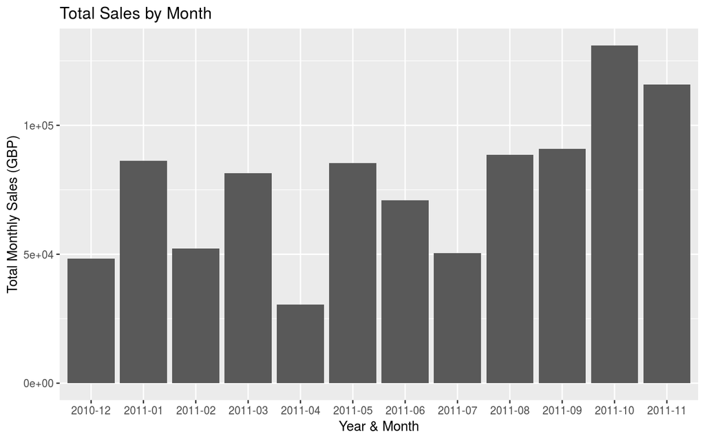

```r
Sales_by_month %>%
  ggplot(aes(x = year_month, y = total_monthly_sales)) +
  geom_col() +
   labs(title = "Total Sales by Month",
        x = "Year & Month",
        y = "Total Monthly Sales (GBP)")
```

First off, I referenced the sales by month data to retrieve the appropriate data. I used a ggplot fucntion to prepare the data and assign axises before using the geom_col function to create the actual bar chart. Finally, I use the labs function and label my title, axises appropriatly. Last, I used the fig.width function in my r section title to manipulate the image size so that my axis markings were user friendly. * https://rstudio.github.io/dygraphs/r-markdown.html

#Honor Pledge On my honor, I have neither given nor received any unacknowledged aid on this assignment. John Schmitt

#Error Log

Exercise 12 I used https://rstudio.github.io/dygraphs/r-markdown.html to learn more about adjusting the figure size, so that labels were readable. Date: 4/23/20 Time:4:30pm

Exercise 11 I used https://statisticsglobe.com/convert-character-to-numeric-in-r/ to learn more about how to convert characters from numeric fields to character fields, and date fields.

Time:4/23/20 Date:12:00pm

Exercise 11 I used https://www.statmethods.net/input/dates.html to learn more about how to format more how to format dates in r. Time:12:30pm Date:4/23/20

YAML I used https://www.stat.berkeley.edu/~s133/dates.html to learn more about how to create a functional YAML Time:2:30pm Date: 4/24/20